# 01_eda

## Cleaning Data & EDA

```python
import pandas as pd
import numpy as np
import matplotlib.pyplot as plt
import seaborn as sns
df = pd.read_csv('../data/Customer-Churn-Records.csv')
```

```python
df = df.drop(columns=["RowNumber", "CustomerId", "Surname"])
df.head(5)
```

|  | CreditScore | Geography | Gender | Age | Tenure | Balance | NumOfProducts | HasCrCard | IsActiveMember | EstimatedSalary | Exited | Complain | Satisfaction Score | Card Type | Point Earned |
| --- | --- | --- | --- | --- | --- | --- | --- | --- | --- | --- | --- | --- | --- | --- | --- |
| 0 | 619 | France | Female | 42 | 2 | 0.00 | 1 | 1 | 1 | 101348.88 | 1 | 1 | 2 | DIAMOND | 464 |
| 1 | 608 | Spain | Female | 41 | 1 | 83807.86 | 1 | 0 | 1 | 112542.58 | 0 | 1 | 3 | DIAMOND | 456 |
| 2 | 502 | France | Female | 42 | 8 | 159660.80 | 3 | 1 | 0 | 113931.57 | 1 | 1 | 3 | DIAMOND | 377 |
| 3 | 699 | France | Female | 39 | 1 | 0.00 | 2 | 0 | 0 | 93826.63 | 0 | 0 | 5 | GOLD | 350 |
| 4 | 850 | Spain | Female | 43 | 2 | 125510.82 | 1 | 1 | 1 | 79084.10 | 0 | 0 | 5 | GOLD | 425 |

```python
print("Shape:", df.shape)
print(df.dtypes)
print("\nMissing Values:")
print(df.isnull().sum())
```

```
Shape: (10000, 15)
CreditScore             int64
Geography              object
Gender                 object
Age                     int64
Tenure                  int64
Balance               float64
NumOfProducts           int64
HasCrCard               int64
IsActiveMember          int64
EstimatedSalary       float64
Exited                  int64
Complain                int64
Satisfaction Score      int64
Card Type              object
Point Earned            int64
dtype: object

Missing Values:
CreditScore           0
Geography             0
Gender                0
Age                   0
Tenure                0
Balance               0
NumOfProducts         0
HasCrCard             0
IsActiveMember        0
EstimatedSalary       0
Exited                0
Complain              0
Satisfaction Score    0
Card Type             0
Point Earned          0
dtype: int64
```

## Churn Distribution

Our data contains 10,000 samples with a churn rate of 20.38% This shows a class imbalance we will need to address when creating the model

```python
churn_value = df['Exited'].value_counts()
churn_rate = df['Exited'].value_counts(normalize=True) * 100

print(churn_value)
print(churn_rate)
```

```
Exited
0    7962
1    2038
Name: count, dtype: int64
Exited
0    79.62
1    20.38
Name: proportion, dtype: float64
```

# EDA

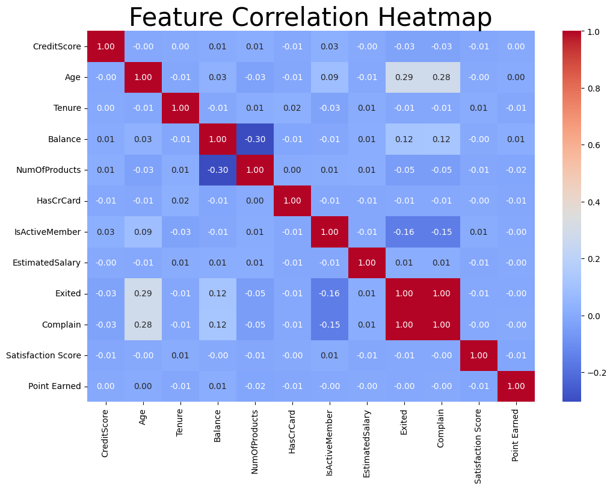

```
Feature Correlation with Churn:
Complain              0.996
Age                   0.285
IsActiveMember       -0.156
Balance               0.119
NumOfProducts        -0.048
CreditScore          -0.027
Tenure               -0.014
EstimatedSalary       0.012
HasCrCard            -0.007
Satisfaction Score   -0.006
Point Earned         -0.005
Name: Exited, dtype: float64
```

```python
plt.figure(figsize=(12, 8))
sns.heatmap(df.corr(numeric_only=True), annot=True, fmt='.2f', cmap='coolwarm')
plt.title('Feature Correlation Heatmap', fontsize=30)
plt.show()

corr_with_churn = df.corr(numeric_only=True)['Exited'].drop('Exited').sort_values(key=abs, ascending=False)
print("Feature Correlation with Churn:")
print(corr_with_churn.round(3))
```

#### **Complaints(0.996)** have nearly a perfect correlation with customer churn, complaints will be the strongest predictor of a customer leaving the bank

#### **Age(0.285)** has a moderately positive correlation, older customers are more likely to church

#### **IsActiveMember(-0.156)** Active members are less likely Churn compared to inactive members

#### **Balance(0.119)** Customers with higher balances are slightly more likely to Churn

#### Features such as **Point Earned**, **Satisfaction Score**, **HasCrCard**, and **Estimated Salary** have negligible correlation and will not be prioritized in the analysis

#### Specifically **Satisfaction Score(-0.006)** nearly has no correlation with customer churn. Meaning the banks current method of evaluating customer satisfcation is not effectively capturing factors that cause customers to leave. So it is reccomended that the bank potentially reworks how it measures customer satisfaction so it can better retain customers

```
Churn Rate by Geography:
Geography
France     16.17
Germany    32.44
Spain      16.67
Name: Exited, dtype: float64
```

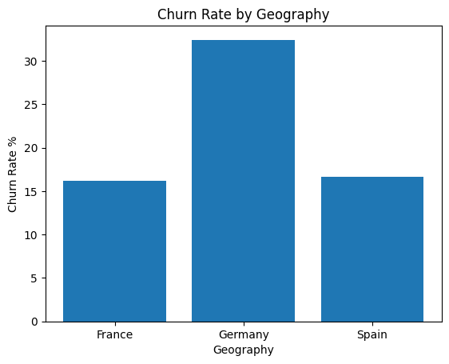

```python
geography_churn = df.groupby('Geography')['Exited'].mean() * 100

print("Churn Rate by Geography:")
print(geography_churn.round(2))

plt.bar(geography_churn.index, geography_churn.values)
plt.title('Churn Rate by Geography')
plt.xlabel('Geography')
plt.ylabel('Churn Rate %')
plt.show()
```

```
Churn Rate by Gender:
Gender
Female    25.07
Male      16.47
Name: Exited, dtype: float64
```

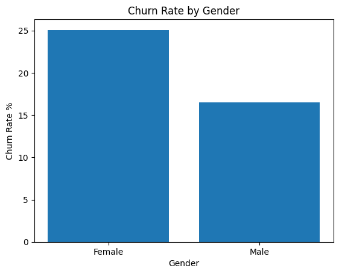

```python
gender_churn = df.groupby("Gender")["Exited"].mean() * 100
print("Churn Rate by Gender:")
print(gender_churn.round(2))

plt.bar(gender_churn.index, gender_churn.values)
plt.title('Churn Rate by Gender')
plt.xlabel('Gender')
plt.ylabel('Churn Rate %')
plt.show()
```

### **Germany** has the highest churn rate at around 32% followed by **France** and **Spain** at about 16%

### **Females** have a significantly higher chance of churning compared to **Males**

## Aside from the nearly 100% correlation of complaints to Churn Rate. Age stands out as one of the most signifcant predictors of Churn rate with a correlation of 0.285

```
Churn Rate by Age:
Age
56    71.43
52    62.75
54    60.71
55    58.54
51    55.46
      ...
81     0.00
83     0.00
85     0.00
88     0.00
92     0.00
Name: Exited, Length: 70, dtype: float64
```

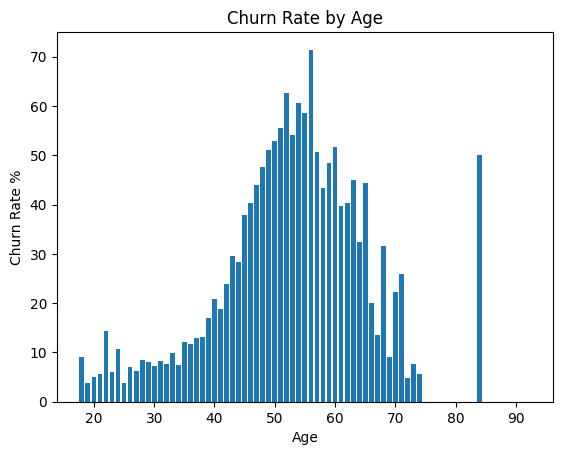

```python
age_churn = df.groupby("Age")["Exited"].mean() * 100
print("Churn Rate by Age:")
print(age_churn.round(2).sort_values(ascending=False))

plt.bar(age_churn.index, age_churn.values)
plt.title('Churn Rate by Age')
plt.xlabel('Age')
plt.ylabel('Churn Rate %')
plt.show()
```

### Based on the graph ages 50-60 tend to have the highest churn rate on average. With the highest being Age 56 at 71.43% followed by Age 52 at 62.75%

### We also observe an outlier between 80 and 90 which will be investigated

```python
print(df[df['Age'] >= 80].shape[0])
df = df[df['Age'] <= 80]
print(f"Rows after removing age outliers: {len(df)}")
```

```
15
Rows after removing age outliers: 9988
```

### New size of the data set is 9988